# Predict Housing Prices using Boosting

## Synopsis

To check and predict housing prices using Boosting, we will make comparsion to other Tree models.

## Analysis

### Loading libraries

```r
library(MASS) # For the Boston dataset
library(gbm)
```

### Run boosted Regression Tree

- We will use `gmb` package to fit boosted regression trees.
- The `gbm()` options will be `distribution="gaussian"` since this is a regression problem.
- For a binary classification problem, we would use `distribution="bernoulli"`.
- The argument `n.trees=5000` indicates that we want 5000 trees.
- The option `interaction.depth=4` limits the depth of each tree.

```r
set.seed(1)
train = sample(1:nrow(Boston), nrow(Boston)/2) # 50% of random data
boston.test <- Boston[-train,"medv"] # The response

boost.boston <- gbm(medv~., data=Boston[train,],
                    distribution="gaussian",
                    n.trees=5000,
                    interaction.depth=4)
```

### Influrence statistics of Boosting Regression Tree

The summary() function produces a relative influence plot and also outputs the relative influence statistics.

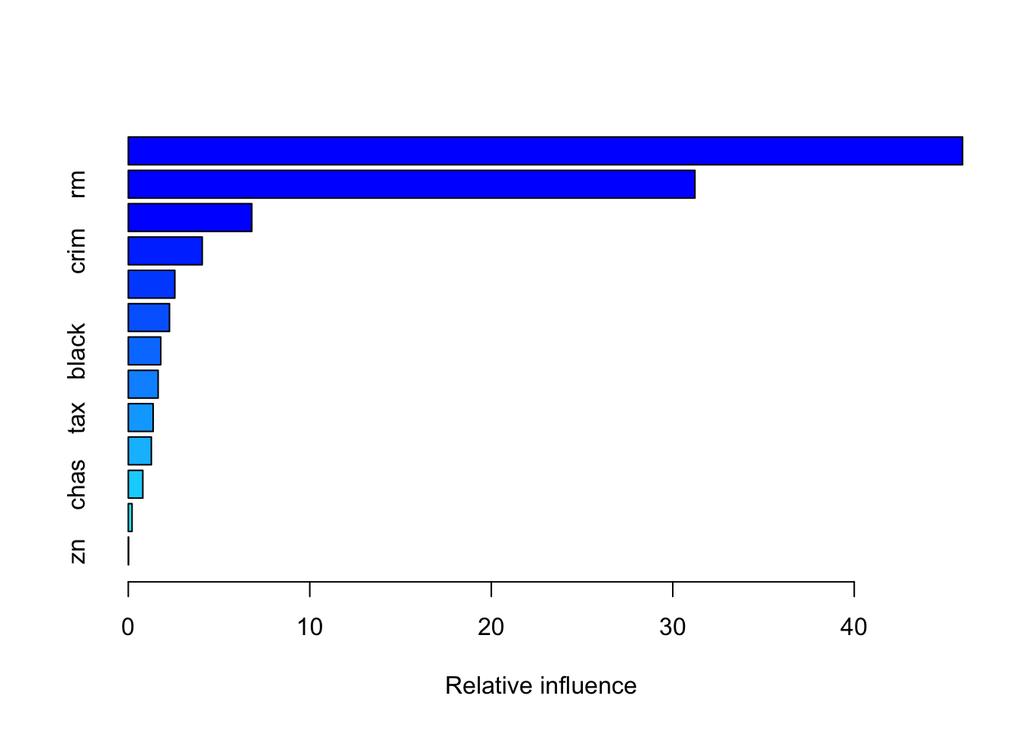

```
##             var     rel.inf
## lstat     lstat 45.96792013
## rm           rm 31.22018272
## dis         dis  6.80567724
## crim       crim  4.07534048
## nox         nox  2.56586166
## ptratio ptratio  2.26983216
## black     black  1.78740116
## age         age  1.64495723
## tax         tax  1.36917603
## indus     indus  1.27052715
## chas       chas  0.80066528
## rad         rad  0.20727091
## zn           zn  0.01518785
```

```r
summary(boost.boston)
```

We see that `lstat` and `rm` are by far the most important variables. `lstat` is not quite in the relative influence plot.

### Plots of Marginal Effect

The plot illustrate the marginal effect of `lstat` and `rm` on the response after integrating out the other variables.

In this case, as we might expect, median house prices are increasing with `rm` and decreasing with `lstat`.

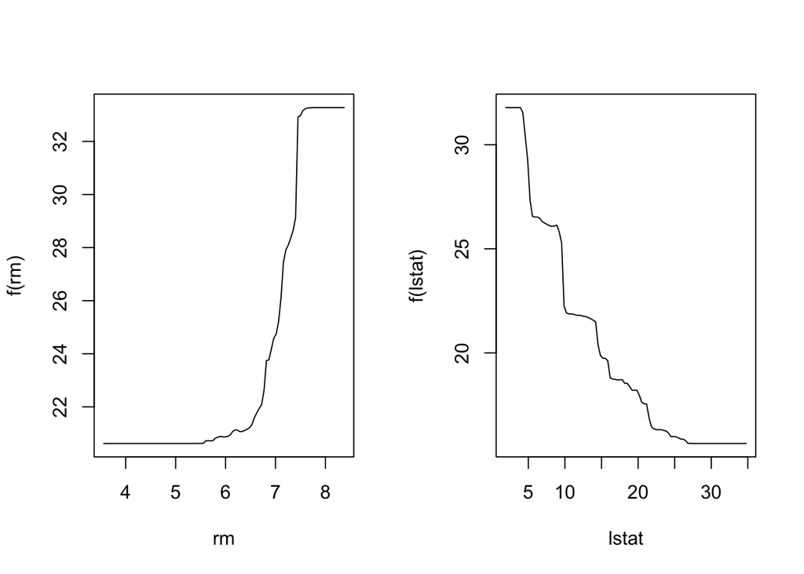

```r
par(mfrow=c(1,2))
plot(boost.boston,i="rm")
plot(boost.boston,i="lstat")
```

### Predict using Boosted Regression Tree

```r
yhat.boost <- predict(boost.boston, newdata=Boston[-train,], n.trees=5000)
mean((yhat.boost-boston.test)^2)
```

```
## [1] 11.84694
```

We can perform boosting with a different value of the shrinkage parameter $\lambda$. The default value is 0.001, but this is easily modified. Here we take $\lambda$ = 0.2.

```r
boost.boston <- gbm(medv~., data=Boston[train,],
                    distribution="gaussian",
                    n.trees=5000,
                    interaction.depth=4,
                    shrinkage=0.2,
                    verbose=F)
```

```r
yhat.boost=predict(boost.boston,newdata=Boston[-train,],n.trees=5000)
mean((yhat.boost-boston.test)^2)
```

```
## [1] 11.42312
```

In this case, using $\lambda=0.2$ leads to a slightly lower test MSE than $\lambda=0.001$.